# Imports + Global Params

```python
####################################
#  Amy Edwards
#  CSC 540
#  Final Project
#  March 18, 2019
#  Code based on Scikit Template
#  created by Casey Bennett 2018,
#  www.CaseyBennett.com
#####################################

import sys
import csv
import math
import numpy as np
from operator import itemgetter
import time
import pandas as pd
import matplotlib.pyplot as plt

from sklearn.ensemble import ExtraTreesClassifier
from sklearn.feature_selection import RFE
from sklearn.linear_model import LogisticRegression
from sklearn.svm import SVC
from sklearn.ensemble import GradientBoostingClassifier, AdaBoostClassifier, GradientBoostingRegressor
from sklearn.neural_network import MLPClassifier
from sklearn.tree import DecisionTreeClassifier, DecisionTreeRegressor
from sklearn.ensemble import RandomForestClassifier, RandomForestRegressor
from sklearn.externals import joblib
from sklearn.feature_selection import RFE, VarianceThreshold, SelectFromModel
from sklearn.feature_selection import SelectKBest, mutual_info_regression, mutual_info_classif, chi2
from sklearn import metrics
from sklearn.model_selection import cross_validate, train_test_split
from sklearn.preprocessing import KBinsDiscretizer, scale, LabelEncoder
from sklearn.model_selection import GridSearchCV

#Handle annoying warnings
import warnings, sklearn.exceptions
warnings.filterwarnings("ignore", category=sklearn.exceptions.ConvergenceWarning)


########################
#
#   Global parameters
#
########################

target_idx= 0                                       #Index of Target variable
cross_val=1                                        #Control Switch for CV
norm_target=0                                       #Normalize target switch
norm_features=0                                     #Normalize feature switch
binning=1                                           #Control Switch for Bin Target
bin_cnt=2                                           #If bin target, this sets number of classes
feat_select=0                                       #Control Switch for Feature Selection
fs_type=3                                          #Feature Selection type (1=Stepwise Backwards Removal, 2=Wrapper Select, 3=Univariate Selection)
lv_filter=0                                         #Control switch for low variance filter on features
feat_start=1                                        #Start column of features
k_cnt=5                                             #Number of 'Top k' best ranked features to select, only applies for fs_types 1 and 3

#Set global model parameters
rand_st=0                                           #Set Random State variable for randomizing splits on runs
```

# Load Data

```python
#####################
#
#    Load Data
#
#####################

file1= csv.reader(open('flights_undersampled.csv'), delimiter=',', quotechar='"')

#Read Header Line
header=next(file1)

#Read data
data=[]
target=[]
for row in file1:
    #Load Target
    if row[target_idx]=='':                         #If target is blank, skip row
        continue
    else:
        target.append(float(row[target_idx]))       #If pre-binned class, change float to int

    #Load row into temp array, cast columns
    temp=[]

    for j in range(feat_start,len(header)):
        if j == target_idx:
            continue
        if row[j]=='':
            temp.append(float())
        else:
            temp.append(float(row[j]))

    #Load temp into Data array
    data.append(temp)

#Test Print
print(header)
print(len(target),len(data))
'''for i in range(10):
    print(target[i])
    print(data[i])'''
print('\n')

data_np=np.asarray(data)
target_np=np.asarray(target)
```

```
['target', 'DISTANCE', 'DIVERTED', 'airline_risk', 'MONTH_2', 'MONTH_3', 'MONTH_4', 'MONTH_5', 'MONTH_6', 'MONTH_7', 'MONTH_8', 'MONTH_9', 'MONTH_10', 'MONTH_11', 'MONTH_12', 'DAY_OF_WEEK_2', 'DAY_OF_WEEK_3', 'DAY_OF_WEEK_4', 'DAY_OF_WEEK_5', 'DAY_OF_WEEK_6', 'DAY_OF_WEEK_7', 'ORIGIN_AIRPORT_ATL', '…
112124 112124
```

## I did some feature selection but stopped using this part so I marked it down

###### #

#

# Feature Selection

#

# Low Variance Filter

if lv_filter==1: print('--LOW VARIANCE FILTER ON--', '\n')

```
#LV Threshold
sel = VarianceThreshold(threshold=0.5)                                      #Removes any feature with less than 20% variance
fit_mod=sel.fit(data_np)
fitted=sel.transform(data_np)
sel_idx=fit_mod.get_support()

#Get lists of selected and non-selected features (names and indexes)
temp=[]
temp_idx=[]
temp_del=[]
for i in range(len(data_np[0])):
    if sel_idx[i]==1:                                                           #Selected Features get added to temp header
        temp.append(header[i+feat_start])
        temp_idx.append(i)
    else:                                                                       #Indexes of non-selected features get added to delete array
        temp_del.append(i)

print('Selected', temp)
print('Features (total, selected):', len(data_np[0]), len(temp))
print('\n')

#Filter selected columns from original dataset
header = header[0:feat_start]
for field in temp:
    header.append(field)
data_np = np.delete(data_np, temp_del, axis=1)                                 #Deletes non-selected features by index
```

# Feature Selection

if feat_select==1: '''Three steps: 1) Run Feature Selection 2) Get lists of selected and non-selected features 3) Filter columns from original dataset '''

```
print('--FEATURE SELECTION ON--', '\n')

##1) Run Feature Selection #######
if fs_type==1:
    #Stepwise Recursive Backwards Feature removal
    if binning==1:
        clf = RandomForestClassifier(n_estimators=75, max_depth=30, min_samples_split=3, criterion='entropy', random_state=None)
        sel = RFE(clf, n_features_to_select=k_cnt, step=.1)
        print('Stepwise Recursive Backwards - Random Forest: ')


    fit_mod=sel.fit(data_np, target_np)
    print(sel.ranking_)
    sel_idx=fit_mod.get_support()

if fs_type==2:
    #Wrapper Select via model
    if binning==1:
        clf = RandomForestClassifier(n_estimators=200, max_depth=None, min_samples_split=3, criterion='entropy', random_state=None)
        sel = SelectFromModel(clf, prefit=False, threshold='mean', max_features=None)                                                           #to select only based on max_features, set to integer value and set threshold=-np.inf
        print ('Wrapper Select - Random Forest: ')

    fit_mod=sel.fit(data_np, target_np)
    sel_idx=fit_mod.get_support()

if fs_type==3:
    if binning==1:                                                              ######Only work if the Target is binned###########
        #Univariate Feature Selection - Chi-squared
        sel=SelectKBest(chi2, k=k_cnt)
        fit_mod=sel.fit(data_np, target_np)                                         #will throw error if any negative values in features, so turn off feature normalization, or switch to mutual_info_classif
        print ('Univariate Feature Selection - Chi2: ')
        sel_idx=fit_mod.get_support()


    #Print ranked variables out sorted
    temp=[]
    scores=fit_mod.scores_
    for i in range(feat_start, len(header)):
        temp.append([header[i], float(scores[i-feat_start])])

    print('Ranked Features')
    temp_sort=sorted(temp, key=itemgetter(1), reverse=True)
    for i in range(len(temp_sort)):
        print(i, temp_sort[i][0], ':', temp_sort[i][1])
    print('\n')

##2) Get lists of selected and non-selected features (names and indexes) #######
temp=[]
temp_idx=[]
temp_del=[]
for i in range(len(data_np[0])):
    if sel_idx[i]==1:                                                           #Selected Features get added to temp header
        temp.append(header[i+feat_start])
        temp_idx.append(i)
    else:                                                                       #Indexes of non-selected features get added to delete array
        temp_del.append(i)
print('Selected', temp)
print('Features (total/selected):', len(data_np[0]), len(temp))
print('\n')


##3) Filter selected columns from original dataset #########
header = header[0:feat_start]
for field in temp:
    header.append(field)
data_np = np.delete(data_np, temp_del, axis=1)                                 #Deletes non-selected features by index)
```

# Train / Test split

```python
##################################
#
#     Train SciKit Models
#
##################################

print('--ML Model Output--', '\n')

# Test/Train split
data_train, data_test, target_train, target_test = train_test_split(data_np, target_np, test_size=0.35)
```

```
--ML Model Output--
```

# Random Forest Model

```python
#########################
###### Classifiers ######
#########################

#dlf = DecisionTreeClassifier(criterion='entropy', splitter='best', max_depth=None, min_samples_split=3, min_samples_leaf=1, max_features=None, random_state=None)
#dlf.fit(data_train, target_train)
#print('Decision Tree Acc:', dlf.score(data_test, target_test))
#print('Decision Tree AUC:', metrics.roc_auc_score(target_test, dlf.predict_proba(data_test)[:,1]))

#SciKit Random Forest
rlf = RandomForestClassifier(n_estimators=75, max_features = 20, max_depth=10, min_samples_split=3, criterion='entropy')
rlf.fit(data_train, target_train)
print('train Random Forest Acc:', rlf.score(data_train, target_train))
print('train Random Forest AUC:', metrics.roc_auc_score(target_train, rlf.predict_proba(data_train)[:,1]))

print('test Random Forest Acc:', rlf.score(data_test, target_test))
print('test Random Forest AUC:', metrics.roc_auc_score(target_test, rlf.predict_proba(data_test)[:,1]))
```

```
train Random Forest Acc: 0.6424396267837541
train Random Forest AUC: 0.6993545131702951
test Random Forest Acc: 0.6251911120171236
test Random Forest AUC: 0.6764334468819325
```

```python
tn, fp, fn, tp  = metrics.confusion_matrix(target_train,(rlf.predict(data_train).round())).ravel()
(tn, fp, fn, tp)
```

```
(22529, 13942, 12117, 24292)
```

```python
tn, fp, fn, tp  = metrics.confusion_matrix(target_test,(rlf.predict(data_test)).round()).ravel()
(tn, fp, fn, tp)
```

```
(11746, 7845, 6864, 12789)
```

# Load Validation Data

```python
#####################
#
#    Load Data
#
#####################

file2= csv.reader(open('validate.csv'), delimiter=',', quotechar='"')

#Read Header Line
header2=next(file2)

#Read data
data2=[]
target2=[]
for row in file2:
    #Load Target
    if row[target_idx]=='':                         #If target is blank, skip row
        continue
    else:
        target2.append(float(row[target_idx]))       #If pre-binned class, change float to int

    #Load row into temp array, cast columns
    temp2=[]

    for j in range(feat_start,len(header2)):
        if j == target_idx:
            continue
        if row[j]=='':
            temp2.append(float())
        else:
            temp2.append(float(row[j]))

    #Load temp into Data array
    data2.append(temp2)

#Test Print
print(header2)
print(len(target2),len(data2))
'''for i in range(10):
    print(target[i])
    print(data[i])'''
print('\n')

data2_np=np.asarray(data2)
target2_np=np.asarray(target2)
```

```
['target', 'DISTANCE', 'DIVERTED', 'airline_risk', 'MONTH_2', 'MONTH_3', 'MONTH_4', 'MONTH_5', 'MONTH_6', 'MONTH_7', 'MONTH_8', 'MONTH_9', 'MONTH_10', 'MONTH_11', 'MONTH_12', 'DAY_OF_WEEK_2', 'DAY_OF_WEEK_3', 'DAY_OF_WEEK_4', 'DAY_OF_WEEK_5', 'DAY_OF_WEEK_6', 'DAY_OF_WEEK_7', 'ORIGIN_AIRPORT_ATL', '…
79502 79502
```

```python
tn, fp, fn, tp  = metrics.confusion_matrix(target2_np,(rlf.predict(data2_np).round())).ravel()
```

```python
(tn, fp, fn, tp)
```

```
(44022, 29184, 2151, 4145)
```

```python
probs = rlf.predict_proba(data2_np).round()
auc = metrics.roc_auc_score(target2_np, probs[:,1])
print('validate Random Forest AUC:', auc)
print('validate  Random Forest Acc:', rlf.score(data2_np, target2_np))
```

```
validate Random Forest AUC: 0.6298493314595935
validate  Random Forest Acc: 0.6058589721013308
```

### Plot ROC curve

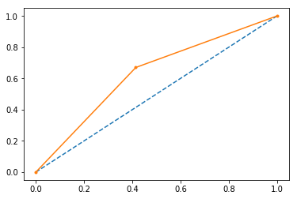

```python
fpr, tpr, thresholds = metrics.roc_curve(target2_np,(probs[:,1]))
# plot no skill
plt.plot([0, 1], [0, 1], linestyle='--')
# plot the roc curve for the model
plt.plot(fpr, tpr, marker='.')
# show the plot
plt.show()
```

### visualize trees

```python
estimator = rlf.estimators_[0]

from sklearn.tree import export_graphviz
# Export as dot file
export_graphviz(estimator, out_file='tree.dot',
                feature_names = ['DISTANCE', 'DIVERTED', 'MONTH_2', 'MONTH_3', 'MONTH_4', 'MONTH_5', 'MONTH_6', 'MONTH_7', 'MONTH_8', 'MONTH_9', 'MONTH_10', 'MONTH_11', 'MONTH_12', 'DAY_OF_WEEK_2', 'DAY_OF_WEEK_3', 'DAY_OF_WEEK_4', 'DAY_OF_WEEK_5', 'DAY_OF_WEEK_6', 'DAY_OF_WEEK_7', 'AIRLINE_AS', 'AIRLINE_B6', 'AIRLINE_DL', 'AIRLINE_EV', 'AIRLINE_F9', 'AIRLINE_HA', 'AIRLINE_MQ', 'AIRLINE_NK', 'AIRLINE_OO', 'AIRLINE_UA', 'AIRLINE_US', 'AIRLINE_VX', 'AIRLINE_WN', 'ORIGIN_AIRPORT_ATL', 'ORIGIN_AIRPORT_AUS', 'ORIGIN_AIRPORT_BDL', 'ORIGIN_AIRPORT_BNA', 'ORIGIN_AIRPORT_BOS', 'ORIGIN_AIRPORT_BUR', 'ORIGIN_AIRPORT_BWI', 'ORIGIN_AIRPORT_CLE', 'ORIGIN_AIRPORT_CLT', 'ORIGIN_AIRPORT_CMH', 'ORIGIN_AIRPORT_CVG', 'ORIGIN_AIRPORT_DAL', 'ORIGIN_AIRPORT_DCA', 'ORIGIN_AIRPORT_DEN', 'ORIGIN_AIRPORT_DFW', 'ORIGIN_AIRPORT_DTW', 'ORIGIN_AIRPORT_EWR', 'ORIGIN_AIRPORT_FLL', 'ORIGIN_AIRPORT_HNL', 'ORIGIN_AIRPORT_HOU', 'ORIGIN_AIRPORT_IAD', 'ORIGIN_AIRPORT_IAH', 'ORIGIN_AIRPORT_IND', 'ORIGIN_AIRPORT_JAX', 'ORIGIN_AIRPORT_JFK', 'ORIGIN_AIRPORT_LAS', 'ORIGIN_AIRPORT_LAX', 'ORIGIN_AIRPORT_LGA', 'ORIGIN_AIRPORT_MCI', 'ORIGIN_AIRPORT_MCO', 'ORIGIN_AIRPORT_MDW', 'ORIGIN_AIRPORT_MIA', 'ORIGIN_AIRPORT_MKE', 'ORIGIN_AIRPORT_MSP', 'ORIGIN_AIRPORT_MSY', 'ORIGIN_AIRPORT_OAK', 'ORIGIN_AIRPORT_OGG', 'ORIGIN_AIRPORT_ONT', 'ORIGIN_AIRPORT_ORD', 'ORIGIN_AIRPORT_PBI', 'ORIGIN_AIRPORT_PDX', 'ORIGIN_AIRPORT_PHL', 'ORIGIN_AIRPORT_PHX', 'ORIGIN_AIRPORT_PIT', 'ORIGIN_AIRPORT_RDU', 'ORIGIN_AIRPORT_RSW', 'ORIGIN_AIRPORT_SAN', 'ORIGIN_AIRPORT_SAT', 'ORIGIN_AIRPORT_SEA', 'ORIGIN_AIRPORT_SFO', 'ORIGIN_AIRPORT_SJC', 'ORIGIN_AIRPORT_SJU', 'ORIGIN_AIRPORT_SLC', 'ORIGIN_AIRPORT_SMF', 'ORIGIN_AIRPORT_SNA', 'ORIGIN_AIRPORT_STL', 'ORIGIN_AIRPORT_TPA', 'DESTINATION_AIRPORT_ATL', 'DESTINATION_AIRPORT_AUS', 'DESTINATION_AIRPORT_BDL', 'DESTINATION_AIRPORT_BNA', 'DESTINATION_AIRPORT_BOS', 'DESTINATION_AIRPORT_BUR', 'DESTINATION_AIRPORT_BWI', 'DESTINATION_AIRPORT_CLE', 'DESTINATION_AIRPORT_CLT', 'DESTINATION_AIRPORT_CMH', 'DESTINATION_AIRPORT_CVG', 'DESTINATION_AIRPORT_DAL', 'DESTINATION_AIRPORT_DCA', 'DESTINATION_AIRPORT_DEN', 'DESTINATION_AIRPORT_DFW', 'DESTINATION_AIRPORT_DTW', 'DESTINATION_AIRPORT_EWR', 'DESTINATION_AIRPORT_FLL', 'DESTINATION_AIRPORT_HNL', 'DESTINATION_AIRPORT_HOU', 'DESTINATION_AIRPORT_IAD', 'DESTINATION_AIRPORT_IAH', 'DESTINATION_AIRPORT_IND', 'DESTINATION_AIRPORT_JAX', 'DESTINATION_AIRPORT_JFK', 'DESTINATION_AIRPORT_LAS', 'DESTINATION_AIRPORT_LAX', 'DESTINATION_AIRPORT_LGA', 'DESTINATION_AIRPORT_MCI', 'DESTINATION_AIRPORT_MCO', 'DESTINATION_AIRPORT_MDW', 'DESTINATION_AIRPORT_MIA', 'DESTINATION_AIRPORT_MKE', 'DESTINATION_AIRPORT_MSP', 'DESTINATION_AIRPORT_MSY', 'DESTINATION_AIRPORT_OAK', 'DESTINATION_AIRPORT_OGG', 'DESTINATION_AIRPORT_ONT', 'DESTINATION_AIRPORT_ORD', 'DESTINATION_AIRPORT_PBI', 'DESTINATION_AIRPORT_PDX', 'DESTINATION_AIRPORT_PHL', 'DESTINATION_AIRPORT_PHX', 'DESTINATION_AIRPORT_PIT', 'DESTINATION_AIRPORT_RDU', 'DESTINATION_AIRPORT_RSW', 'DESTINATION_AIRPORT_SAN', 'DESTINATION_AIRPORT_SAT', 'DESTINATION_AIRPORT_SEA', 'DESTINATION_AIRPORT_SFO', 'DESTINATION_AIRPORT_SJC', 'DESTINATION_AIRPORT_SJU', 'DESTINATION_AIRPORT_SLC', 'DESTINATION_AIRPORT_SMF', 'DESTINATION_AIRPORT_SNA', 'DESTINATION_AIRPORT_STL', 'DESTINATION_AIRPORT_TPA', 'SCHEDULED_DEPARTURE_2', 'SCHEDULED_DEPARTURE_3', 'SCHEDULED_DEPARTURE_4'],
                class_names = 'target',
                rounded = True, proportion = False,
                precision = 2, filled = True)
```

```python
import pydot

(graph,) = pydot.graph_from_dot_file('tree.dot')
graph.write_png('img10.png')
```

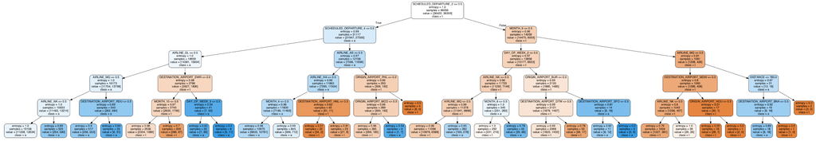

```python
#from subprocess import call
#call(['dot', '-Tpng', 'tree.dot', '-o', 'img.png', '-Gdpi=600'])

# Display in python
import matplotlib.pyplot as plt
plt.figure(figsize = (140, 180))
plt.imshow(plt.imread('img5.png'))
plt.axis('off');
plt.show();
```

# Other things I did but I stopped using

from sklearn.preprocessing import StandardScaler scaler = StandardScaler()

# Fit on training set only.

scaler.fit(data_train)

# Apply transform to both the training set and the test set.

data_train = scaler.transform(data_train) data_test = scaler.transform(data_test)

from sklearn.decomposition import PCA

# Make an instance of the Model

pca = PCA(.95)

pca.fit(data_train)

data_train = pca.transform(data_train) data_test = pca.transform(data_test)

### used the grid search to get params and then put them back into stepwise

Tried the random forest with grid search params + features selected using stepwise and univariate before grid search, and AUC decreased.

grid_search = GridSearchCV(estimator=classifier,  
param_grid=grid_param, scoring='accuracy', cv=5, n_jobs=-1)

(n_estimators=75, max_depth=30, min_samples_split=3, criterion='entropy') Random Forest Acc: 0.6433346839546191 Random Forest AUC: 0.6970337314263082 array([[28919, 7919], [ 6731, 29765]]) array([[12128, 7445], [ 6639, 13276]])

#### CV = 1 BIN = 1

# Setup Crossval classifier scorers

if bin_cnt<=2: scorers = {'Accuracy': 'accuracy', 'roc_auc': 'roc_auc'} else: scorers = {'Accuracy': 'accuracy'}

# SciKit Gradient Boosting - Cross Val

start_ts=time.time()  
glf=GradientBoostingClassifier(loss = 'deviance', n_estimators = 100, learning_rate = 0.1, max_depth = 10, min_samples_split = 3, random_state = rand_st) scores = cross_validate(glf, data_np, y = target_np, scoring = scorers, cv = 5)

# SciKit Ada Boosting - Cross Val

alf=AdaBoostClassifier(n_estimators = 100, learning_rate = 0.1, base_estimator = None, random_state = rand_st) scores = cross_validate(alf, data_np, y = target_np, scoring = scorers, cv = 5) scores_Acc = scores['test_Accuracy']  
print("Ada Boosting Acc: %0.2f (+/- %0.2f)" % (scores_Acc.mean(), scores_Acc.std() * 2))  
if bin_cnt<=2:  
scores_AUC= scores['test_roc_auc']

```
#Only works with binary classes, not multiclass
print("Ada Boosting AUC: %0.2f (+/- %0.2f)" % (scores_AUC.mean(), scores_AUC.std() * 2))
```

print("CV Runtime:", time.time()-start_ts)

# SciKit Neural Network - Cross Val

nlf=MLPClassifier(activation = 'logistic', alpha = 0.01, solver = 'adam', max_iter = 250, hidden_layer_sizes = (10,), random_state = rand_st) scores = cross_validate(nlf, data_np, y = target_np, scoring = scorers, cv = 20) scores_Acc = scores['test_Accuracy']  
print("Neural Network Acc: %0.2f (+/- %0.2f)" % (scores_Acc.mean(), scores_Acc.std() * 2))  
if bin_cnt<=2:  
scores_AUC= scores['test_roc_auc']

```
#Only works with binary classes, not multiclass
print("Neural Network AUC: %0.2f (+/- %0.2f)" % (scores_AUC.mean(), scores_AUC.std() * 2))
```

print("CV Runtime:", time.time()-start_ts)

### Notes

Testing out parameters

with univariate - all about the same. chose 5/148 features Selected ['MONTH_9', 'MONTH_10', 'AIRLINE_DL', 'SCHEDULED_DEPARTURE_2', 'SCHEDULED_DEPARTURE_4'] Features (total/selected): 148 5 Decision Tree Acc: 0.5945438396142622 Decision Tree AUC: 0.6191335658511657 Random Forest Acc: 0.5945438396142622 Random Forest AUC: 0.6191335658511657 20 cv Gradient Boosting Acc: 0.59 (+/- 0.01) Gradient Boosting AUC: 0.62 (+/- 0.01) CV Runtime: 100.68650412559509 Ada Boosting Acc: 0.59 (+/- 0.01) Ada Boosting AUC: 0.62 (+/- 0.01) CV Runtime: 187.22866487503052 Neural Network Acc: 0.59 (+/- 0.01) Neural Network AUC: 0.62 (+/- 0.01) CV Runtime: 190.80271100997925 5cv Gradient Boosting Acc: 0.59 (+/- 0.00) Gradient Boosting AUC: 0.62 (+/- 0.00) CV Runtime: 21.263638973236084 Ada Boosting Acc: 0.59 (+/- 0.00) Ada Boosting AUC: 0.62 (+/- 0.00) CV Runtime: 39.9906280040741 Neural Network Acc: 0.59 (+/- 0.00) Neural Network AUC: 0.62 (+/- 0.00) CV Runtime: 199.61156392097473

with wrapper - takes too long! - chose 49/148 features Selected ['MONTH_2', 'MONTH_3', 'MONTH_4', 'MONTH_5', 'MONTH_6', 'MONTH_7', 'MONTH_8', 'MONTH_9', 'MONTH_10', 'MONTH_11', 'MONTH_12', 'DAY_OF_WEEK_2', 'DAY_OF_WEEK_3', 'DAY_OF_WEEK_4', 'DAY_OF_WEEK_5', 'DAY_OF_WEEK_6', 'DAY_OF_WEEK_7', 'AIRLINE_DL', 'AIRLINE_OO', 'AIRLINE_UA', 'AIRLINE_WN', 'ORIGIN_AIRPORT_ATL', 'ORIGIN_AIRPORT_BOS', 'ORIGIN_AIRPORT_DCA', 'ORIGIN_AIRPORT_DEN', 'ORIGIN_AIRPORT_DFW', 'ORIGIN_AIRPORT_LAS', 'ORIGIN_AIRPORT_LAX', 'ORIGIN_AIRPORT_MCO', 'ORIGIN_AIRPORT_ORD', 'ORIGIN_AIRPORT_PHX', 'ORIGIN_AIRPORT_SFO', 'DESTINATION_AIRPORT_ATL', 'DESTINATION_AIRPORT_BOS', 'DESTINATION_AIRPORT_DCA', 'DESTINATION_AIRPORT_DEN', 'DESTINATION_AIRPORT_DFW', 'DESTINATION_AIRPORT_FLL', 'DESTINATION_AIRPORT_LAS', 'DESTINATION_AIRPORT_LAX', 'DESTINATION_AIRPORT_LGA', 'DESTINATION_AIRPORT_MCO', 'DESTINATION_AIRPORT_ORD', 'DESTINATION_AIRPORT_PHX', 'DESTINATION_AIRPORT_SAN', 'DESTINATION_AIRPORT_SFO', 'SCHEDULED_DEPARTURE_2', 'SCHEDULED_DEPARTURE_3', 'SCHEDULED_DEPARTURE_4']

Decision Tree Acc: 0.5945438396142622 Decision Tree AUC: 0.6101170170971687 Random Forest Acc: 0.6095419363024996 Random Forest AUC: 0.6434165151093232

5 cross fold waited an hour and stopped

stepwise backward 5/148 ['MONTH_2', 'AIRLINE_DL', 'SCHEDULED_DEPARTURE_2', 'SCHEDULED_DEPARTURE_3', 'SCHEDULED_DEPARTURE_4'] Decision Tree Acc: 0.5942646872224338 Decision Tree AUC: 0.6175894570803411 Random Forest Acc: 0.5942646872224338 Random Forest AUC: 0.6175721404691146 20 cv Gradient Boosting Acc: 0.60 (+/- 0.01) Gradient Boosting AUC: 0.62 (+/- 0.01) CV Runtime: 91.31592988967896 Ada Boosting Acc: 0.59 (+/- 0.01) Ada Boosting AUC: 0.61 (+/- 0.01) CV Runtime: 178.08745002746582 Neural Network Acc: 0.59 (+/- 0.01) Neural Network AUC: 0.62 (+/- 0.01) CV Runtime: 96.0439190864563 5 cv Gradient Boosting Acc: 0.59 (+/- 0.00) Gradient Boosting AUC: 0.62 (+/- 0.00) CV Runtime: 21.783344745635986 Ada Boosting Acc: 0.59 (+/- 0.00) Ada Boosting AUC: 0.62 (+/- 0.00) CV Runtime: 40.820597887039185 Neural Network Acc: 0.59 (+/- 0.00) Neural Network AUC: 0.62 (+/- 0.00) CV Runtime: 195.6875159740448

no feature selection: Decision Tree Acc: 0.580657414910859 Decision Tree AUC: 0.587744446108704 Random Forest Acc: 0.6301154781199352 Random Forest AUC: 0.681215288359783

--- too many features for other methods Neural Network Acc: 0.64 (+/- 0.01) Neural Network AUC: 0.70 (+/- 0.01) CV Runtime: 2131.391662120819